# Исследование экспрессии различных белков у мышей с синдромом дауна

Дарья Халенёва

2/23/2021

## О проекте

Датасет содержит информацию о 77 белках, уровень экспрессии которых был измерен для мышей в коре мозга в норме и при синдроме дауна. всего в эксперименте участвовало 72 мыши, среди которых 38 контрольных мышей и 34 трисомических мыши (синдром Дауна). Для каждой мыши каждый белок измерялся 15 раз. Таким образом, данные содержат в общей сложности 1080 измерений на белок. Каждое измерение рассматривалось как независимый образец.

При этом все мыши были разделены на 8 классов:

- Генотип: контроль (c) или трисомия (t)
- Поведение: стимулировались (C/S) или не стимулировались (S/C) к обучению
- Лечение: препарат мемантин (m) или препарат салин (s)

**Задачи проекта**:

1. Сделать описание датасета
2. Определить, есть ли различия в уровне продукции BDNF_N в зависимости от класса в эксперименте
3. Построить линейную модель, способную предсказать уровень продукции белка ERBB4_N на основании данных о других белках в эксперименте
4. Провести анализ главных компонент (PCA)
5. Произвести поиск дифференциальных белков

## Начало работы

Перед началом работы подключим все необходимые библиотеки:

```r
library(randomForest)
library(ggplot2)
library(readxl)
library(vegan)
library(dplyr)
library(grid)
library(car)
library(rgl)
```

Посмотрим на структуру датасета:

```
## tibble [1,080 × 82] (S3: tbl_df/tbl/data.frame)
##  $ MouseID        : chr [1:1080] "309_1" "309_2" "309_3" "309_4" ...
##  $ DYRK1A_N       : num [1:1080] 0.504 0.515 0.509 0.442 0.435 ...
##  $ ITSN1_N        : num [1:1080] 0.747 0.689 0.73 0.617 0.617 ...
##  $ BDNF_N         : num [1:1080] 0.43 0.412 0.418 0.359 0.359 ...
##  $ NR1_N          : num [1:1080] 2.82 2.79 2.69 2.47 2.37 ...
##  $ NR2A_N         : num [1:1080] 5.99 5.69 5.62 4.98 4.72 ...
##  $ pAKT_N         : num [1:1080] 0.219 0.212 0.209 0.223 0.213 ...
##  $ pBRAF_N        : num [1:1080] 0.178 0.173 0.176 0.176 0.174 ...
##  $ pCAMKII_N      : num [1:1080] 2.37 2.29 2.28 2.15 2.13 ...
##  $ pCREB_N        : num [1:1080] 0.232 0.227 0.23 0.207 0.192 ...
##  $ pELK_N         : num [1:1080] 1.75 1.6 1.56 1.6 1.5 ...
##  $ pERK_N         : num [1:1080] 0.688 0.695 0.677 0.583 0.551 ...
##  $ pJNK_N         : num [1:1080] 0.306 0.299 0.291 0.297 0.287 ...
##  $ PKCA_N         : num [1:1080] 0.403 0.386 0.381 0.377 0.364 ...
```

[output cut: 68 more lines]

Изучая структуру данных, устанавливаем, что каждому белку соответствует отдельная колонка, где в численном виде представлен уровень его экспрессии, также отдельно указаны все признаки мыши - Genotype, Treatment и Behavior. Наконец, отдельно указан класс мыши как комбинация трех этих признаков.

У каждой мыши есть уникальный ID, он прописан в отдельной колонке MouseID, с пометкой о каждом новом измерении уровня экспрессии (по 15 для каждой мыши)

## Описание датасета

### Определение групп наблюдений

Определим, сбалансированны ли наблюдения по классам мышей, и какова структура распределения измерений:

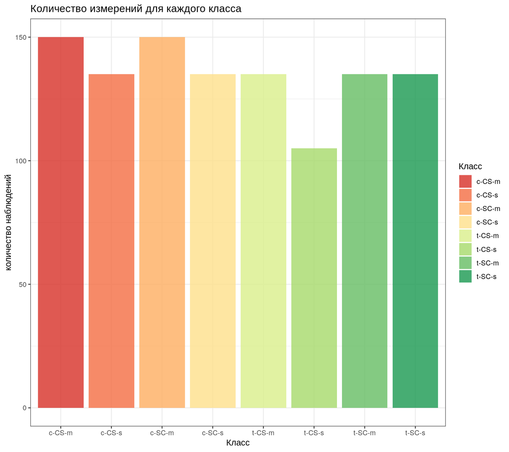

Исходя из полученного графика, видно, что наблюдения по классам распределены более менее равномерно.

### Поиск пропущенных значений

Определим, сколько пропущенных значений содержат данные:

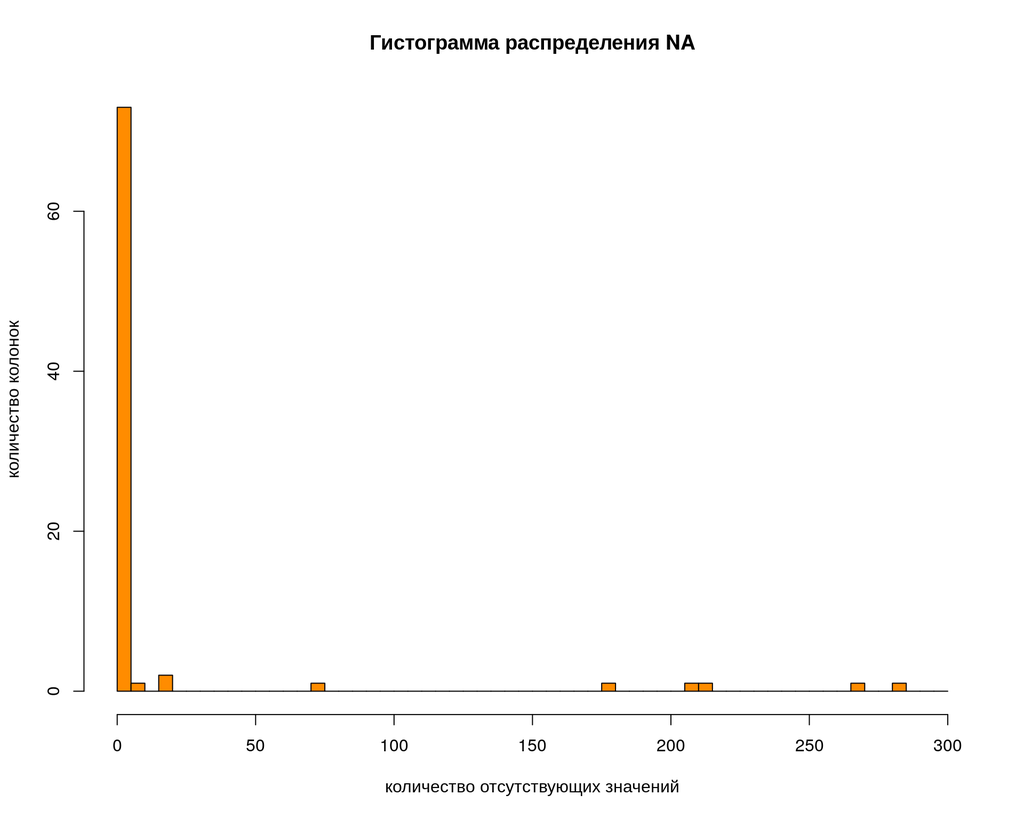

### Очистка данных

Большая часть данных не содержит пропущенных значений, однако, отдельные колонки имеют более 150 пропусков, что составляет ощутимый процент от 1080 значений (около 15%). Найдем эти колонки:

```r
cat(names(data)[colSums(is.na(data))>150])
```

```
## BAD_N BCL2_N H3AcK18_N EGR1_N H3MeK4_N
```

Получили белки, для которых пропущенных значений оказалось больше 150. Такое большое число пропущенных значений будет некорректно заполнять вручную, поэтому эти белки были исключены из дальнейшего анализа.

```r
prots  <-  names(data)[0<=colSums(is.na(data))&colSums(is.na(data))<150]
prots <- prots[!prots %in% c("Genotype", "Treatment", "Behavior", "class", "MouseID")]
prots
```

```
##  [1] "DYRK1A_N"        "ITSN1_N"         "BDNF_N"          "NR1_N"
##  [5] "NR2A_N"          "pAKT_N"          "pBRAF_N"         "pCAMKII_N"
##  [9] "pCREB_N"         "pELK_N"          "pERK_N"          "pJNK_N"
## [13] "PKCA_N"          "pMEK_N"          "pNR1_N"          "pNR2A_N"
## [17] "pNR2B_N"         "pPKCAB_N"        "pRSK_N"          "AKT_N"
## [21] "BRAF_N"          "CAMKII_N"        "CREB_N"          "ELK_N"
## [25] "ERK_N"           "GSK3B_N"         "JNK_N"           "MEK_N"
## [29] "TRKA_N"          "RSK_N"           "APP_N"           "Bcatenin_N"
## [33] "SOD1_N"          "MTOR_N"          "P38_N"           "pMTOR_N"
## [37] "DSCR1_N"         "AMPKA_N"         "NR2B_N"          "pNUMB_N"
## [41] "RAPTOR_N"        "TIAM1_N"         "pP70S6_N"        "NUMB_N"
## [45] "P70S6_N"         "pGSK3B_N"        "pPKCG_N"         "CDK5_N"
## [49] "S6_N"            "ADARB1_N"        "AcetylH3K9_N"    "RRP1_N"
## [53] "BAX_N"           "ARC_N"           "ERBB4_N"         "nNOS_N"
## [57] "Tau_N"           "GFAP_N"          "GluR3_N"         "GluR4_N"
## [61] "IL1B_N"          "P3525_N"         "pCASP9_N"        "PSD95_N"
## [65] "SNCA_N"          "Ubiquitin_N"     "pGSK3B_Tyr216_N" "SHH_N"
## [69] "pS6_N"           "pCFOS_N"         "SYP_N"           "CaNA_N"
```

Эти белки содержат некоторое количество пропущенных значений, которые будут заменены на медианные. Также, следует привести в порядок типы некоторых колонок, в частности, сделать категориальные значения факторами:

```r
data$Genotype <- as.factor(data$Genotype)
data$Treatment <- as.factor(data$Treatment)
data$Behavior <- as.factor(data$Behavior)
data$class <- as.factor(data$class)

for(i in 1:length(prots)){
  data[prots[i]][is.na(data[prots[i]])] <- median(unlist(data[prots[i]]), na.rm=TRUE)
}
```

## Исследование данных

### Поиск различий в уровне продукции BDNF_N в зависимости от класса в эксперименте

Визуализируем уровень продукции белка BDNF в зависимости от класса мышей:

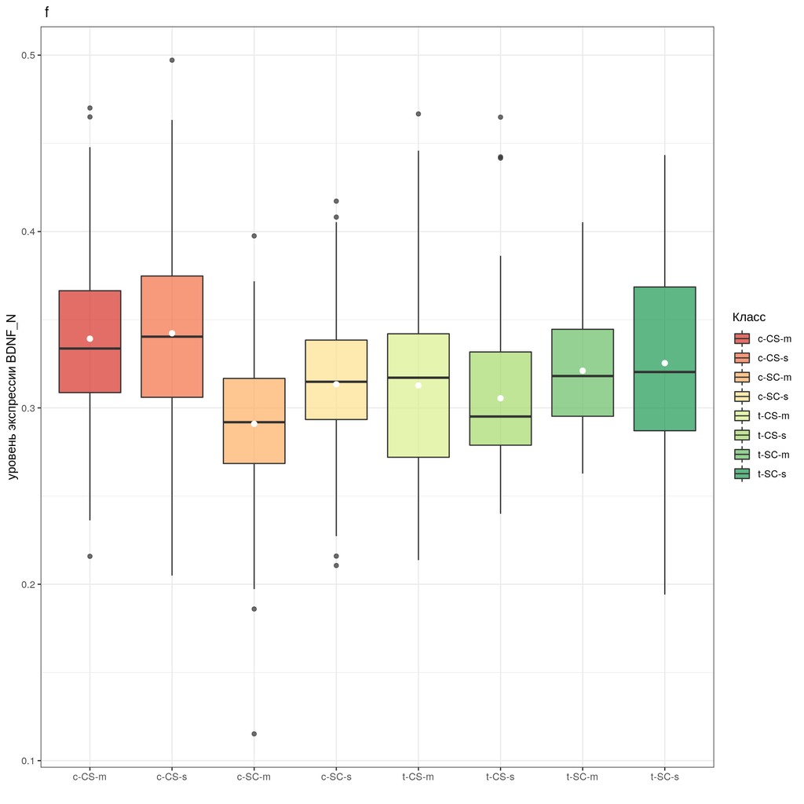

Для того, чтобы убедиться, что для белка BDNF существует хотя бы одно значимое отличие по продукции в зависимости от класса, произведем анализ вариации ANOVA. Поскольку классов у нас 8, необходимо сделать поправку уровня значимости.

```
## Уровень значимости после поправки Бонферрони:  0.004375
```

```r
Analysis <- aov(BDNF_N ~ class, data = data)
 summary(Analysis)
```

```
##               Df Sum Sq Mean Sq F value Pr(>F)
## class          7 0.2876 0.04109   18.85 <2e-16 ***
## Residuals   1072 2.3364 0.00218
## ---
## Signif. codes:  0 '***' 0.001 '**' 0.01 '*' 0.05 '.' 0.1 ' ' 1
```

```r
t_test <- pairwise.t.test(as.vector(unlist(data$BDNF_N)), data$class, p.adjust = "none")
t_test$p.value < bonf
```

```
##        c-CS-m c-CS-s c-SC-m c-SC-s t-CS-m t-CS-s t-SC-m
## c-CS-s  FALSE     NA     NA     NA     NA     NA     NA
## c-SC-m   TRUE   TRUE     NA     NA     NA     NA     NA
## c-SC-s   TRUE   TRUE   TRUE     NA     NA     NA     NA
## t-CS-m   TRUE   TRUE   TRUE  FALSE     NA     NA     NA
## t-CS-s   TRUE   TRUE  FALSE  FALSE  FALSE     NA     NA
## t-SC-m   TRUE   TRUE   TRUE  FALSE  FALSE  FALSE     NA
## t-SC-s  FALSE   TRUE   TRUE  FALSE  FALSE   TRUE  FALSE
```

Нулевая гипотеза для ANOVA гласила, что между исследуемыми классами нет значимых различий в продукции белка BDNF. Альтернативная гипотеза заключала, что среди исследуемых классов есть хотя бы два, которые значимо различаются.

в столбце Pr(>F) представлена вероятность получить F-значение, равное или превышающее то значение, которое мы рассчитали по имеющимся выборочным данным (при условии, что нулевая гипотеза верна).

Видно, что эта вероятность очень мала, следовательно, мы отвергаем нулевую гипотезу. Исходя из парного t-теста, значимые различия есть между 16 парами классов мышей.

### Построение линейной модели, предсказывающей уровень продукции белка ERBB4_N на основании данных о других белках в эксперименте

```r
model <- lm(ERBB4_N ~ ., data=data[prots])
summary(model) # спрятана, потому что очень длинная
```

Adjusted R-squared: 0.8033 Полная модель объясняет большой процент изменчивости, однако, здесь присутствуют компоненты, вклад которых пренебрежительно мал, и в дальнейшем их можно будет отбросить.

#### Диагностика модели

Построим график отклонений остатков модели

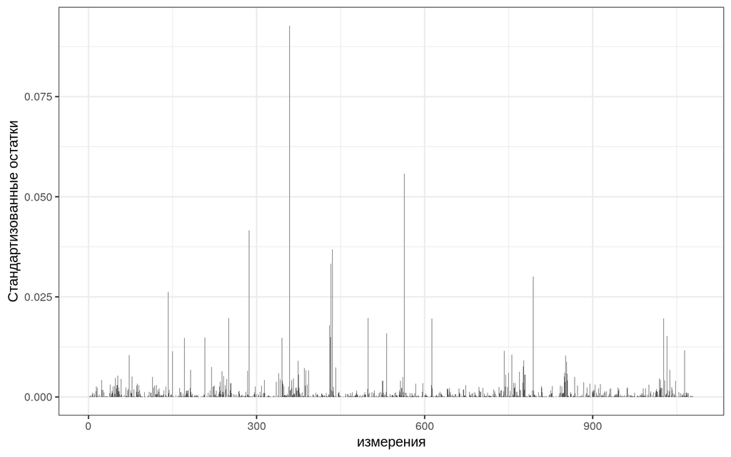

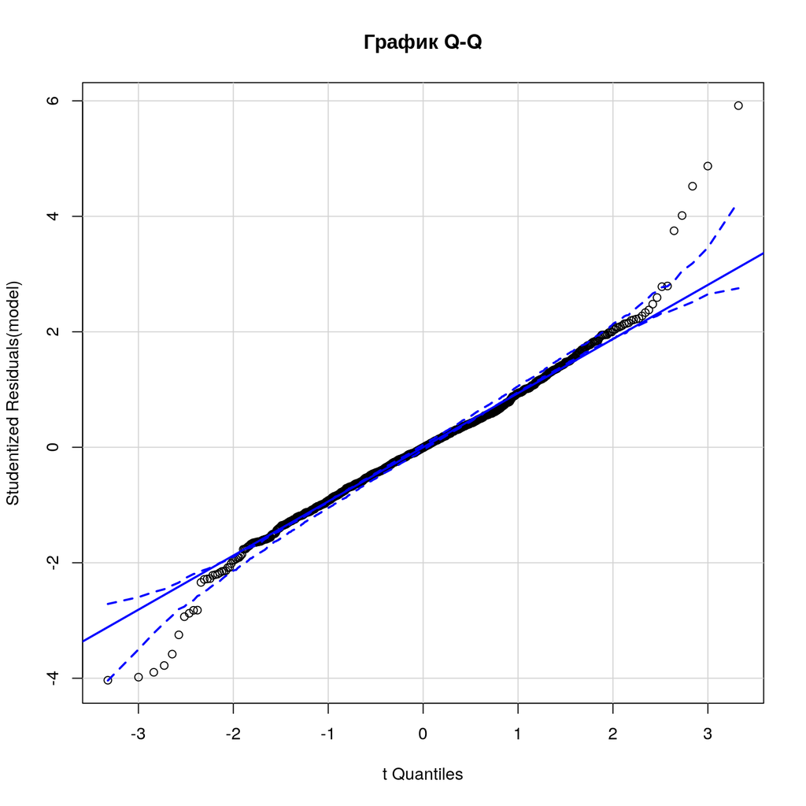

Видно, что присутствуют выбросы

### Подбор наилучшей модели

После того, как мы проанализировали полную модель, мы можем попытаться найти лучший способ предсказать экспрессию гена ERBB4_N, используя наши предикторы. Один из способов создания хорошей модели - это пошаговый выбор, когда мы начинаем с нашей полной модели и идем в обратном направлении, повторно используя количество предикторов с самыми большими AIC:

```r
backw_mod <- step(model, direction = "backward")
```

Итоговая модель, которую подобрал step:

```r
summary(backw_mod)
```

```
##
## Call:
## lm(formula = ERBB4_N ~ DYRK1A_N + ITSN1_N + NR1_N + pAKT_N +
##     pBRAF_N + pCREB_N + pJNK_N + PKCA_N + pNR1_N + pNR2B_N +
##     pRSK_N + AKT_N + BRAF_N + CAMKII_N + ERK_N + RSK_N + SOD1_N +
##     MTOR_N + pMTOR_N + TIAM1_N + NUMB_N + P70S6_N + pGSK3B_N +
##     pPKCG_N + CDK5_N + AcetylH3K9_N + RRP1_N + ARC_N + Tau_N +
##     GFAP_N + GluR3_N + GluR4_N + IL1B_N + P3525_N + pCASP9_N +
##     PSD95_N + pGSK3B_Tyr216_N + pCFOS_N + SYP_N + CaNA_N, data = data[prots])
##
## Residuals:
##       Min        1Q    Median        3Q       Max
## -0.025709 -0.003978 -0.000020  0.003569  0.038343
##
## Coefficients:
##                   Estimate Std. Error t value Pr(>|t|)
## (Intercept)      0.0240427  0.0048967   4.910 1.06e-06 ***
## DYRK1A_N        -0.0100809  0.0048521  -2.078 0.037990 *
## ITSN1_N          0.0137989  0.0049142   2.808 0.005079 **
## NR1_N           -0.0077384  0.0033616  -2.302 0.021533 *
## pAKT_N           0.0318813  0.0128447   2.482 0.013220 *
## pBRAF_N         -0.0486097  0.0191913  -2.533 0.011458 *
## pCREB_N         -0.0406464  0.0151615  -2.681 0.007459 **
## pJNK_N          -0.0350359  0.0112561  -3.113 0.001905 **
## PKCA_N           0.0522988  0.0117726   4.442 9.85e-06 ***
## pNR1_N          -0.0141404  0.0078409  -1.803 0.071615 .
## pNR2B_N          0.0065503  0.0026276   2.493 0.012826 *
## pRSK_N           0.0114372  0.0069903   1.636 0.102109
## AKT_N            0.0107227  0.0044405   2.415 0.015918 *
## BRAF_N          -0.0114544  0.0054298  -2.110 0.035138 *
## CAMKII_N         0.0257700  0.0112601   2.289 0.022302 *
## ERK_N            0.0042460  0.0011266   3.769 0.000173 ***
## RSK_N            0.0295581  0.0210649   1.403 0.160858
## SOD1_N          -0.0019988  0.0013254  -1.508 0.131830
## MTOR_N           0.0374476  0.0087240   4.292 1.93e-05 ***
## pMTOR_N         -0.0106608  0.0044210  -2.411 0.016064 *
## TIAM1_N         -0.0186498  0.0079545  -2.345 0.019238 *
## NUMB_N          -0.0296539  0.0190016  -1.561 0.118924
## P70S6_N         -0.0065121  0.0030536  -2.133 0.033195 *
## pGSK3B_N         0.0562362  0.0224503   2.505 0.012400 *
```

[output cut: 8 more lines]

```
## GluR4_N         -0.0220590  0.0106591  -2.069 0.038746 *
## IL1B_N           0.0213771  0.0064362   3.321 0.000927 ***
## P3525_N          0.0950034  0.0124223   7.648 4.64e-14 ***
## pCASP9_N         0.0126716  0.0017528   7.229 9.39e-13 ***
## PSD95_N          0.0174207  0.0017820   9.776  < 2e-16 ***
## pGSK3B_Tyr216_N  0.0239271  0.0046488   5.147 3.17e-07 ***
## pCFOS_N         -0.0419448  0.0138386  -3.031 0.002498 **
## SYP_N            0.0213629  0.0051394   4.157 3.49e-05 ***
## CaNA_N          -0.0065107  0.0018024  -3.612 0.000318 ***
## ---
## Signif. codes:  0 '***' 0.001 '**' 0.01 '*' 0.05 '.' 0.1 ' ' 1
##
## Residual standard error: 0.006621 on 1039 degrees of freedom
## Multiple R-squared:  0.8142, Adjusted R-squared:  0.807
## F-statistic: 113.8 on 40 and 1039 DF,  p-value: < 2.2e-16
```

Adjusted R-squared: 0.807

В итоговой модели осталось довольно много предикторов, и анализировать ее вручную неудобно.

### Проведение анализа главных компонент (PCA)

Для начала определим главные компоненты для наших данных.

```r
data <- tibble(data)


data.pca <- rda(data[prots],
                scale = TRUE)
```

Определим, сколько компонент нам стоит оставить для анализа. Собственные числа для каждой из компонент:

```r
eigenvals(data.pca)
```

```
##       PC1       PC2       PC3       PC4       PC5       PC6       PC7       PC8
## 19.457287 11.762923  7.837259  5.338937  3.555951  3.431666  2.492692  2.277732
##       PC9      PC10      PC11      PC12      PC13      PC14      PC15      PC16
##  1.704208  1.244526  1.090882  0.916923  0.822897  0.761761  0.647452  0.603072
##      PC17      PC18      PC19      PC20      PC21      PC22      PC23      PC24
##  0.579202  0.497095  0.434724  0.424405  0.412597  0.383920  0.353197  0.328783
##      PC25      PC26      PC27      PC28      PC29      PC30      PC31      PC32
##  0.290803  0.280990  0.253161  0.245185  0.231291  0.211691  0.178468  0.172987
##      PC33      PC34      PC35      PC36      PC37      PC38      PC39      PC40
##  0.168651  0.167458  0.149212  0.148272  0.131161  0.121862  0.119786  0.117322
##      PC41      PC42      PC43      PC44      PC45      PC46      PC47      PC48
##  0.116364  0.108373  0.098703  0.092599  0.089790  0.082863  0.079990  0.078706
##      PC49      PC50      PC51      PC52      PC53      PC54      PC55      PC56
##  0.072857  0.067919  0.061968  0.058517  0.057272  0.053167  0.052320  0.049542
##      PC57      PC58      PC59      PC60      PC61      PC62      PC63      PC64
##  0.047814  0.043173  0.039605  0.037427  0.036906  0.035243  0.031910  0.027526
##      PC65      PC66      PC67      PC68      PC69      PC70      PC71
##  0.025934  0.025114  0.020758  0.017315  0.015598  0.015126  0.011206
```

И соответствующий график для собственных чисел:

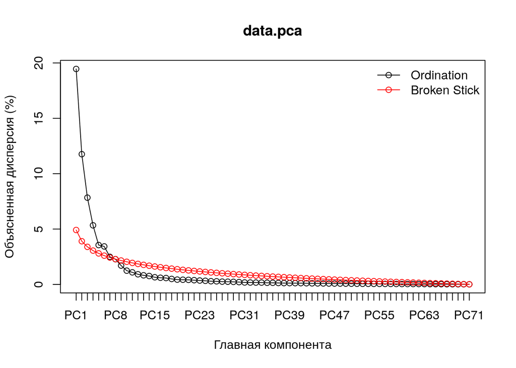

#### Определение процента изменчивости, объясненного каждой компонентой

```r
x <- prcomp(data[,prots], center=TRUE, scale.=TRUE)
summary(x)
```

```
## Importance of components:
##                           PC1    PC2    PC3     PC4     PC5     PC6     PC7
## Standard deviation     4.4110 3.4297 2.7995 2.31061 1.88572 1.85248 1.57883
## Proportion of Variance 0.2702 0.1634 0.1089 0.07415 0.04939 0.04766 0.03462
## Cumulative Proportion  0.2702 0.4336 0.5425 0.61662 0.66600 0.71367 0.74829
##                            PC8     PC9    PC10    PC11    PC12    PC13    PC14
## Standard deviation     1.50922 1.30545 1.11558 1.04445 0.95756 0.90714 0.87279
## Proportion of Variance 0.03164 0.02367 0.01729 0.01515 0.01274 0.01143 0.01058
## Cumulative Proportion  0.77992 0.80359 0.82088 0.83603 0.84876 0.86019 0.87077
##                           PC15    PC16    PC17   PC18    PC19    PC20    PC21
## Standard deviation     0.80464 0.77658 0.76105 0.7050 0.65934 0.65146 0.64234
## Proportion of Variance 0.00899 0.00838 0.00804 0.0069 0.00604 0.00589 0.00573
## Cumulative Proportion  0.87977 0.88814 0.89619 0.9031 0.90913 0.91502 0.92075
##                           PC22    PC23    PC24    PC25   PC26    PC27    PC28
## Standard deviation     0.61961 0.59430 0.57340 0.53926 0.5301 0.50315 0.49516
## Proportion of Variance 0.00533 0.00491 0.00457 0.00404 0.0039 0.00352 0.00341
## Cumulative Proportion  0.92608 0.93099 0.93556 0.93960 0.9435 0.94701 0.95042
##                           PC29    PC30    PC31   PC32    PC33    PC34    PC35
## Standard deviation     0.48093 0.46010 0.42245 0.4159 0.41067 0.40922 0.38628
## Proportion of Variance 0.00321 0.00294 0.00248 0.0024 0.00234 0.00233 0.00207
## Cumulative Proportion  0.95363 0.95657 0.95905 0.9615 0.96380 0.96612 0.96819
##                           PC36    PC37    PC38    PC39    PC40    PC41    PC42
## Standard deviation     0.38506 0.36216 0.34909 0.34610 0.34252 0.34112 0.32920
## Proportion of Variance 0.00206 0.00182 0.00169 0.00166 0.00163 0.00162 0.00151
## Cumulative Proportion  0.97025 0.97208 0.97377 0.97543 0.97706 0.97868 0.98018
##                           PC43    PC44    PC45    PC46    PC47    PC48    PC49
## Standard deviation     0.31417 0.30430 0.29965 0.28786 0.28283 0.28055 0.26992
## Proportion of Variance 0.00137 0.00129 0.00125 0.00115 0.00111 0.00109 0.00101
## Cumulative Proportion  0.98155 0.98284 0.98409 0.98524 0.98635 0.98744 0.98845
##                           PC50    PC51    PC52   PC53    PC54    PC55    PC56
## Standard deviation     0.26061 0.24893 0.24190 0.2393 0.23058 0.22873 0.22258
## Proportion of Variance 0.00094 0.00086 0.00081 0.0008 0.00074 0.00073 0.00069
## Cumulative Proportion  0.98940 0.99026 0.99107 0.9919 0.99260 0.99333 0.99402
##                           PC57   PC58    PC59    PC60    PC61    PC62    PC63
## Standard deviation     0.21866 0.2078 0.19901 0.19346 0.19211 0.18773 0.17863
## Proportion of Variance 0.00066 0.0006 0.00055 0.00052 0.00051 0.00049 0.00044
## Cumulative Proportion  0.99468 0.9953 0.99583 0.99635 0.99686 0.99735 0.99780
##                           PC64    PC65    PC66    PC67    PC68    PC69    PC70
## Standard deviation     0.16591 0.16104 0.15848 0.14408 0.13159 0.12489 0.12299
## Proportion of Variance 0.00038 0.00036 0.00035 0.00029 0.00024 0.00022 0.00021
## Cumulative Proportion  0.99818 0.99854 0.99889 0.99918 0.99942 0.99963 0.99984
##                           PC71      PC72
## Standard deviation     0.10586 1.959e-15
## Proportion of Variance 0.00016 0.000e+00
## Cumulative Proportion  1.00000 1.000e+00
```

Исходя из полученных результатов, видно, что первая главная компонента объясняет 27% дисперсии, вторая 16%, третья - 10% и так далее.

#### График факторных нагрузок

Построим график факторных нагрузок:

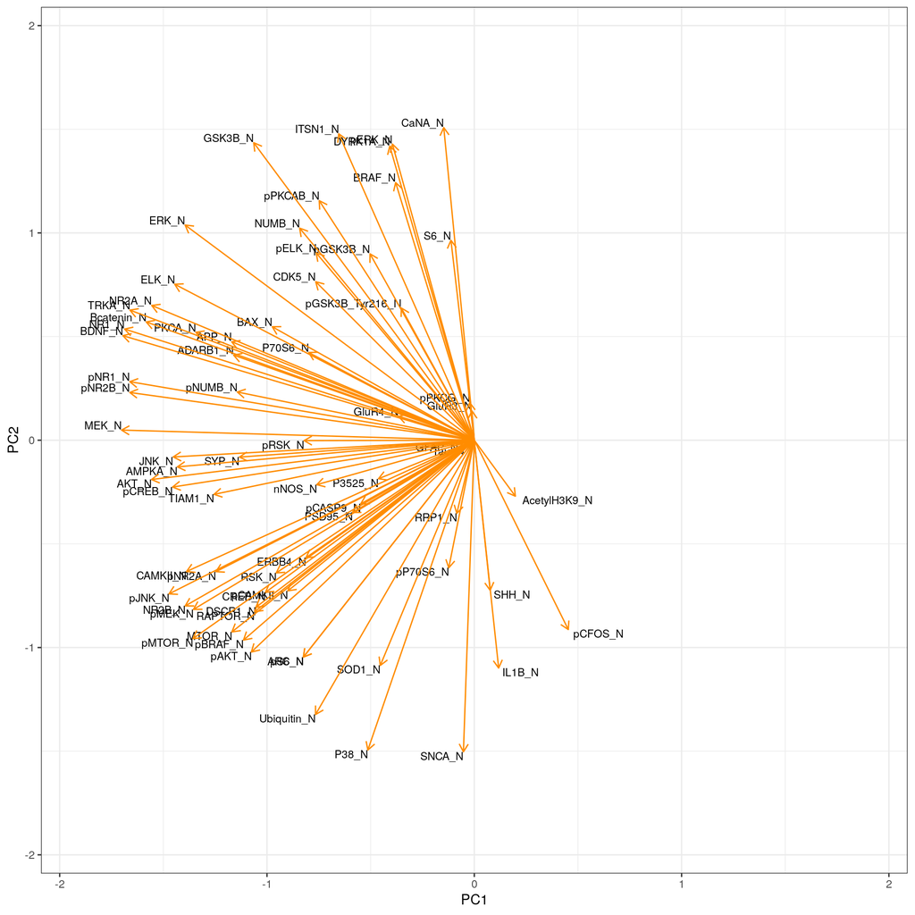

#### График ординации

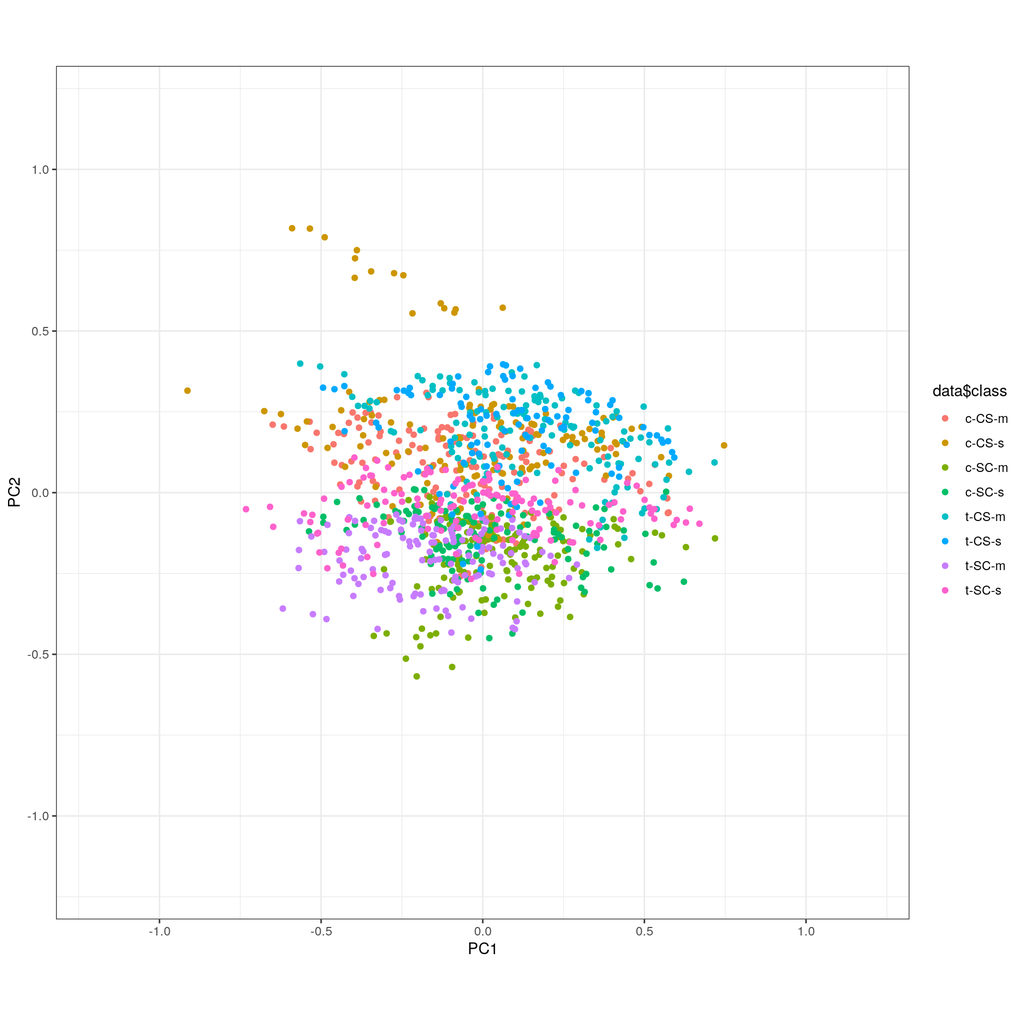

#### 3D Визуализация графика по трем главным компонентам

Полученный результат - скриншот графика, сам график интерактивен.

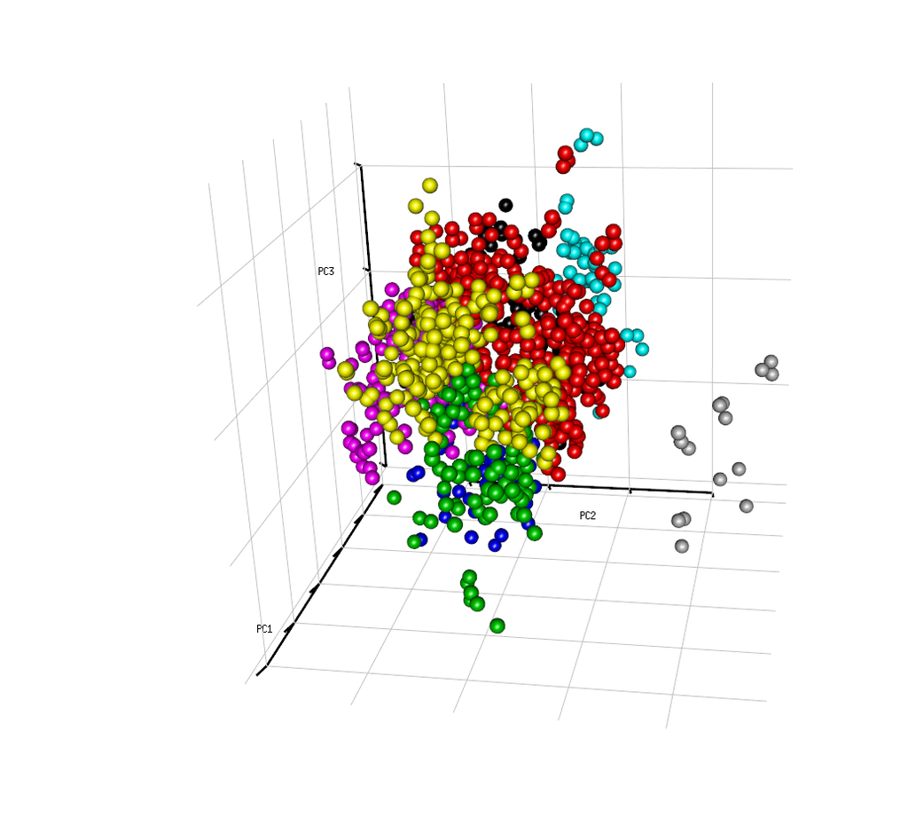

Рис.1. Визуализация графика PCA для трехмерного пространства

### Дополнительно: построим RandomForest модель для предсказания продукции ERBB4_N и сравним с линейной моделью

Перед созданием RF модели, разделим нашу выборку на ту, на которой будем обучать модель (тренировочную) и на ту, на которой будем проверять точность модели (тестовую):

```r
samp_size <- floor(0.75 *nrow(data))
set.seed(43)
train_inds <- sample(seq_len(nrow(data)), size = samp_size)

train <- data[train_inds, prots]
test <- data[-train_inds, prots]
```

Задание параметров RandomForest модели:

```r
model <- randomForest(formula = ERBB4_N ~ DYRK1A_N + ITSN1_N + NR1_N + pAKT_N +
    pBRAF_N + pCREB_N + pJNK_N + PKCA_N + pNR1_N + pNR2B_N +
    pRSK_N + AKT_N + BRAF_N + CAMKII_N + ERK_N + RSK_N + SOD1_N +
    MTOR_N + pMTOR_N + TIAM1_N + NUMB_N + P70S6_N + pGSK3B_N +
    pPKCG_N + CDK5_N + AcetylH3K9_N + RRP1_N + ARC_N + Tau_N +
    GFAP_N + GluR3_N + GluR4_N + IL1B_N + P3525_N + pCASP9_N +
    PSD95_N + pGSK3B_Tyr216_N + pCFOS_N + SYP_N + CaNA_N,
             ntree=700,
             data=train,
             importance=TRUE)

model
```

```
##
## Call:
##  randomForest(formula = ERBB4_N ~ DYRK1A_N + ITSN1_N + NR1_N +      pAKT_N + pBRAF_N + pCREB_N + pJNK_N + PKCA_N + pNR1_N + pNR2B_N +      pRSK_N + AKT_N + BRAF_N + CAMKII_N + ERK_N + RSK_N + SOD1_N +      MTOR_N + pMTOR_N + TIAM1_N + NUMB_N + P70S6_N + pGSK3B_N +      pPKCG_N + CDK5_N + AcetylH3…
##                Type of random forest: regression
##                      Number of trees: 700
## No. of variables tried at each split: 13
##
##           Mean of squared residuals: 4.948441e-05
##                     % Var explained: 78.26
```

```r
y_pred = predict(model, test)
```

Задание параметров lm модели:

```r
lin_model <- lm(formula = ERBB4_N ~ DYRK1A_N + ITSN1_N + NR1_N + pAKT_N +
    pBRAF_N + pCREB_N + pJNK_N + PKCA_N + pNR1_N + pNR2B_N +
    pRSK_N + AKT_N + BRAF_N + CAMKII_N + ERK_N + RSK_N + SOD1_N +
    MTOR_N + pMTOR_N + TIAM1_N + NUMB_N + P70S6_N + pGSK3B_N +
    pPKCG_N + CDK5_N + AcetylH3K9_N + RRP1_N + ARC_N + Tau_N +
    GFAP_N + GluR3_N + GluR4_N + IL1B_N + P3525_N + pCASP9_N +
    PSD95_N + pGSK3B_Tyr216_N + pCFOS_N + SYP_N + CaNA_N, data = train)

y_lin_pred = predict(lin_model, test)
```

```
## средняя абсолютная ошибка для RandomForest =  0.0005178517 , для Lm =  0.00100755
```

По результатам сравнения двух моделей, одна из которых была получена ранее, видно, что RandomForest модель лучше предсказывает данные. Для модели RandomForest были взяты те же предикторы, что и для отобранной линейной модели.